# Publication figure report

Author

Affiliation

none

manual

**Important**

A manual command generated this report without an LLM model. No separate human scientific review is part of this fixed recipe. The report records the selected recipe and does not claim a new statistical method.

## Figure

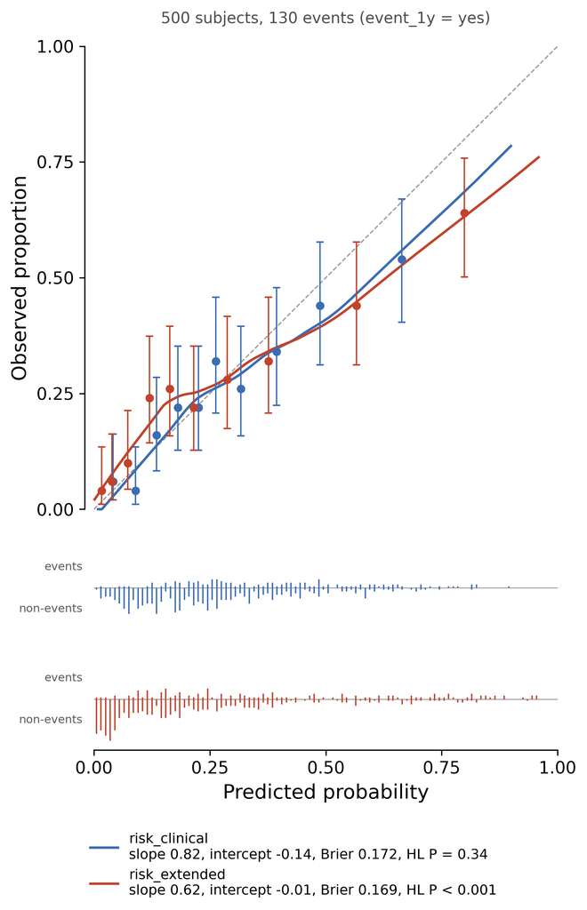

Publication figure

## Statistical results

| model | case_level | n | n_events | brier | intercept | intercept_ci_low | intercept_ci_high | slope | slope_ci_low | slope_ci_high | hl_statistic | hl_df | hl_p | hl_groups | oe_ratio |
| --- | --- | --- | --- | --- | --- | --- | --- | --- | --- | --- | --- | --- | --- | --- | --- |
| risk_clinical | yes | 500 | 130 | 0.17178516214 | -0.14396939979698375 | -0.3624515229281368 | 0.0745127233341693 | 0.8214088301669082 | 0.5924935047766039 | 1.0503241555572125 | 9.021355696342091 | 8 | 0.3404976192295656 | 10 | 0.9162808302068186 |
| risk_extended | yes | 500 | 130 | 0.16879814044 | -0.012445103058084404 | -0.25171434979707 | 0.2268241436809012 | 0.6216320036108007 | 0.4670073527191929 | 0.7762566545024085 | 26.95551206512255 | 8 | 0.0007196003369925088 | 10 | 0.9936057647477846 |

## Methods

The calibration of the predicted probabilities was assessed against the observed outcome event_1y = yes (events, n = 130) versus no (non-events, n = 370). For each model, the Brier score is the mean squared difference between the prediction and the outcome. The calibration intercept (calibration-in-the-large) is the intercept of a logistic regression of the outcome with logit(p) as an offset, and the calibration slope is the coefficient of logit(p) in a logistic regression, each with a 95% Wald CI; ideal values are 0 and 1. The Hosmer-Lemeshow test grouped the subjects at the deciles of the prediction (g = 10; tied deciles merge, df = groups - 2). The figure shows the observed proportion against the mean prediction in each group with a 95% Wilson CI, a lowess smooth of the outcome on the prediction (f = 2/3, without robustness iterations, which would treat the events of a binary outcome as outliers), and the spike histogram of the predictions. risk_clinical: Brier score 0.172, calibration intercept -0.14 (95% CI -0.36 to 0.07), slope 0.82 (95% CI 0.59 to 1.05), Hosmer-Lemeshow chi-square(8) = 9.02, P = 0.34, observed/expected 0.92; risk_extended: Brier score 0.169, calibration intercept -0.01 (95% CI -0.25 to 0.23), slope 0.62 (95% CI 0.47 to 0.78), Hosmer-Lemeshow chi-square(8) = 26.96, P < 0.001, observed/expected 0.99. Computed in Python 3.10.12 with statsmodels 0.15.0, grouping as ResourceSelection::hoslem.test does, and drawn with matplotlib 3.10.9.

## Plot configuration

The complete plot configuration is in `plot_config.yaml`.

## Provenance

| field | value |
| --- | --- |
| repository | pubready |
| repository_version | 4.0.0 |
| git_commit | 567ce8900bdb5db88369d131c8d787b042b3af57 |
| git_dirty | FALSE |
| llm_provider | none |
| llm_model | none |
| agent_harness | manual |
| agent_harness_version | not_recorded |
| container_image | localhost/pubready:4.0.0 |
| container_digest | sha256:0f57027a3fbca5ec9d41d74ca91226fbdf45d94b1a85f271637d12733db5d483 |
| input | {“file”: “input_event_1y_risk_clinical_risk_extended.csv”, “md5”: “4d7ddf64a4e0eb79c7d2003021d46c53”, “sha256”: “c6d02e1cfda0e27a2779f352e23b00abe6c739ee1b810ad3e9113fdcdc55e34b”} |
| command | figkit plot –recipe calibration |
| analysis_options | {“engine”: “python”, “recipe”: “calibration”, “data”: {“file”: “calibration.csv”, “x”: “risk_clinical,risk_extended”, “y”: “event_1y”, “fill”: null, “facet”: null, “time”: null, “event”: null, “annota… |
| random_seeds | not_applicable |
| session_record | session_info.txt |
| created_utc | 2026-07-18T00:00:00Z |
| review_state | not_applicable |
| reviewer | none |
| quarto_version | 1.11.4 |

The report source reads only files in this bundle.